# regression

Naresh

September 3, 2016

## R Markdown

ISLR practice Working on regression

```r
library(MASS)
library(ISLR)
```

working on simple linear regression with boston data

```r
attach(Boston)
names(Boston)
```

```
##  [1] "crim"    "zn"      "indus"   "chas"    "nox"     "rm"      "age"
##  [8] "dis"     "rad"     "tax"     "ptratio" "black"   "lstat"   "medv"
```

```r
str(Boston)
```

```
## 'data.frame':    506 obs. of  14 variables:
##  $ crim   : num  0.00632 0.02731 0.02729 0.03237 0.06905 ...
##  $ zn     : num  18 0 0 0 0 0 12.5 12.5 12.5 12.5 ...
##  $ indus  : num  2.31 7.07 7.07 2.18 2.18 2.18 7.87 7.87 7.87 7.87 ...
##  $ chas   : int  0 0 0 0 0 0 0 0 0 0 ...
##  $ nox    : num  0.538 0.469 0.469 0.458 0.458 0.458 0.524 0.524 0.524 0.524 ...
##  $ rm     : num  6.58 6.42 7.18 7 7.15 ...
##  $ age    : num  65.2 78.9 61.1 45.8 54.2 58.7 66.6 96.1 100 85.9 ...
##  $ dis    : num  4.09 4.97 4.97 6.06 6.06 ...
##  $ rad    : int  1 2 2 3 3 3 5 5 5 5 ...
##  $ tax    : num  296 242 242 222 222 222 311 311 311 311 ...
##  $ ptratio: num  15.3 17.8 17.8 18.7 18.7 18.7 15.2 15.2 15.2 15.2 ...
##  $ black  : num  397 397 393 395 397 ...
##  $ lstat  : num  4.98 9.14 4.03 2.94 5.33 ...
##  $ medv   : num  24 21.6 34.7 33.4 36.2 28.7 22.9 27.1 16.5 18.9 ...
```

```r
summary(Boston)
```

```
##       crim                zn             indus            chas
##  Min.   : 0.00632   Min.   :  0.00   Min.   : 0.46   Min.   :0.00000
##  1st Qu.: 0.08204   1st Qu.:  0.00   1st Qu.: 5.19   1st Qu.:0.00000
##  Median : 0.25651   Median :  0.00   Median : 9.69   Median :0.00000
##  Mean   : 3.61352   Mean   : 11.36   Mean   :11.14   Mean   :0.06917
##  3rd Qu.: 3.67708   3rd Qu.: 12.50   3rd Qu.:18.10   3rd Qu.:0.00000
##  Max.   :88.97620   Max.   :100.00   Max.   :27.74   Max.   :1.00000
##       nox               rm             age              dis
##  Min.   :0.3850   Min.   :3.561   Min.   :  2.90   Min.   : 1.130
##  1st Qu.:0.4490   1st Qu.:5.886   1st Qu.: 45.02   1st Qu.: 2.100
##  Median :0.5380   Median :6.208   Median : 77.50   Median : 3.207
##  Mean   :0.5547   Mean   :6.285   Mean   : 68.57   Mean   : 3.795
##  3rd Qu.:0.6240   3rd Qu.:6.623   3rd Qu.: 94.08   3rd Qu.: 5.188
##  Max.   :0.8710   Max.   :8.780   Max.   :100.00   Max.   :12.127
##       rad              tax           ptratio          black
##  Min.   : 1.000   Min.   :187.0   Min.   :12.60   Min.   :  0.32
##  1st Qu.: 4.000   1st Qu.:279.0   1st Qu.:17.40   1st Qu.:375.38
##  Median : 5.000   Median :330.0   Median :19.05   Median :391.44
##  Mean   : 9.549   Mean   :408.2   Mean   :18.46   Mean   :356.67
##  3rd Qu.:24.000   3rd Qu.:666.0   3rd Qu.:20.20   3rd Qu.:396.23
##  Max.   :24.000   Max.   :711.0   Max.   :22.00   Max.   :396.90
##      lstat            medv
##  Min.   : 1.73   Min.   : 5.00
##  1st Qu.: 6.95   1st Qu.:17.02
##  Median :11.36   Median :21.20
##  Mean   :12.65   Mean   :22.53
##  3rd Qu.:16.95   3rd Qu.:25.00
##  Max.   :37.97   Max.   :50.00
```

simple linear regression with medv as dependent variable and lstat as predictor variable by attaching the dataset , we don’t need to mention it again and again

```r
lstatModel=lm(medv~lstat,data=Boston)
lstatModel
```

```
##
## Call:
## lm(formula = medv ~ lstat, data = Boston)
##
## Coefficients:
## (Intercept)        lstat
##       34.55        -0.95
```

```r
summary(lstatModel)
```

```
##
## Call:
## lm(formula = medv ~ lstat, data = Boston)
##
## Residuals:
##     Min      1Q  Median      3Q     Max
## -15.168  -3.990  -1.318   2.034  24.500
##
## Coefficients:
##             Estimate Std. Error t value Pr(>|t|)
## (Intercept) 34.55384    0.56263   61.41   <2e-16 ***
## lstat       -0.95005    0.03873  -24.53   <2e-16 ***
## ---
## Signif. codes:  0 '***' 0.001 '**' 0.01 '*' 0.05 '.' 0.1 ' ' 1
##
## Residual standard error: 6.216 on 504 degrees of freedom
## Multiple R-squared:  0.5441, Adjusted R-squared:  0.5432
## F-statistic: 601.6 on 1 and 504 DF,  p-value: < 2.2e-16
```

```r
names(lstatModel)
```

```
##  [1] "coefficients"  "residuals"     "effects"       "rank"
##  [5] "fitted.values" "assign"        "qr"            "df.residual"
##  [9] "xlevels"       "call"          "terms"         "model"
```

```r
coef(lstatModel)
```

```
## (Intercept)       lstat
##  34.5538409  -0.9500494
```

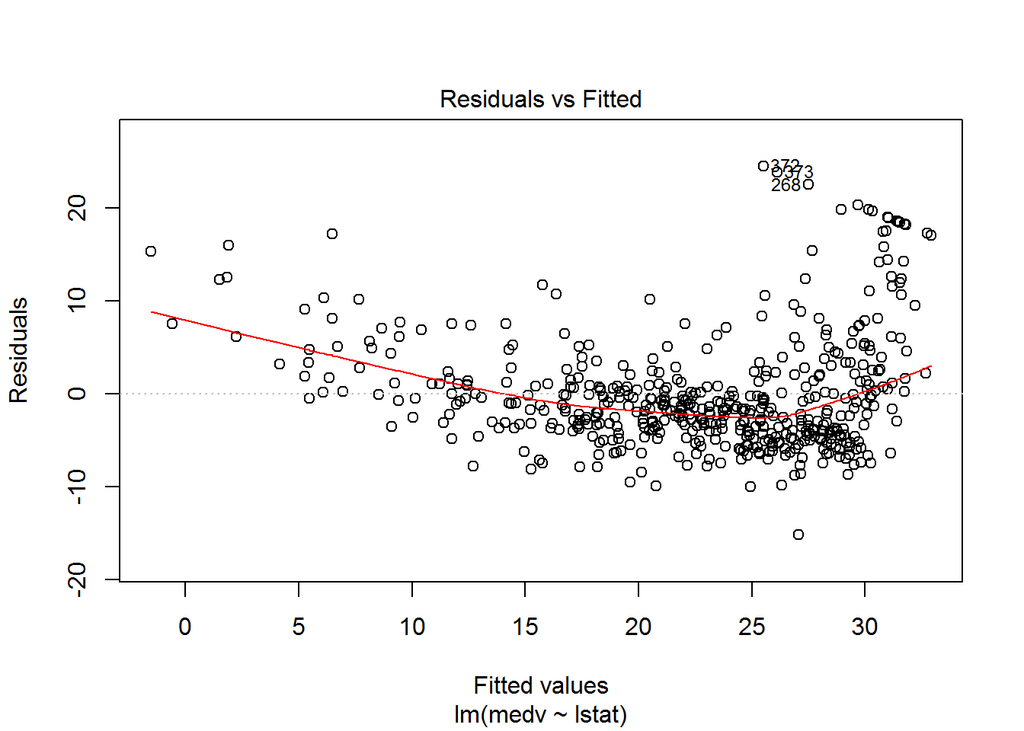

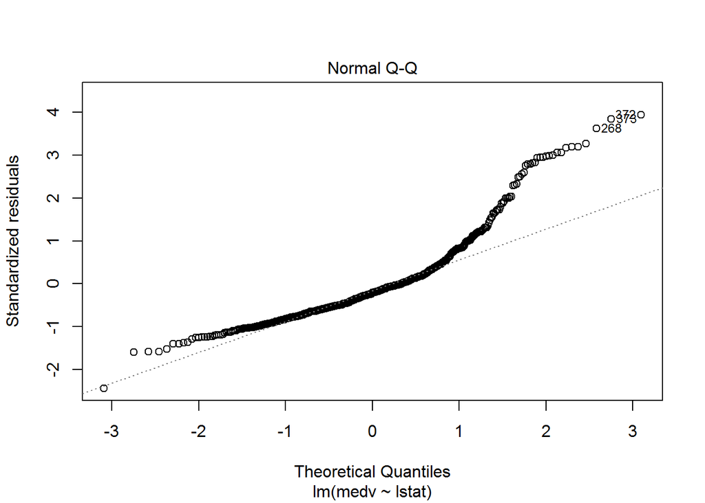

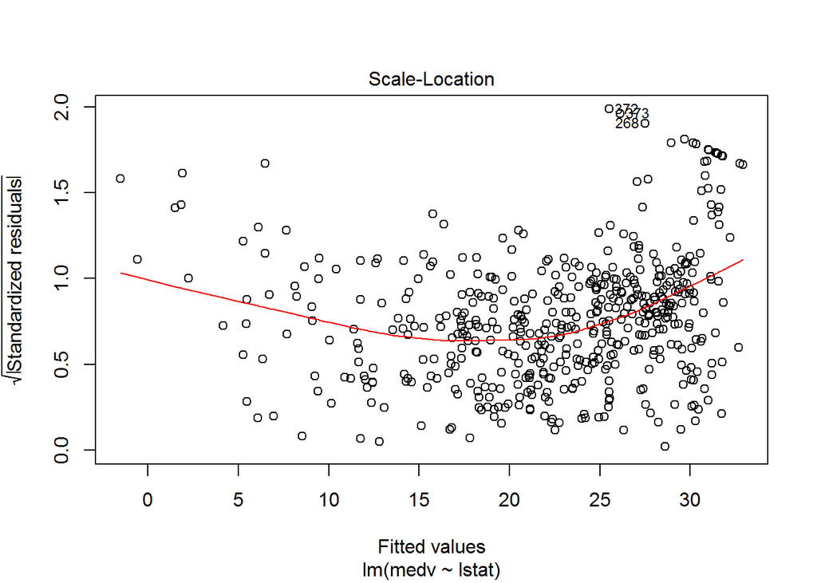

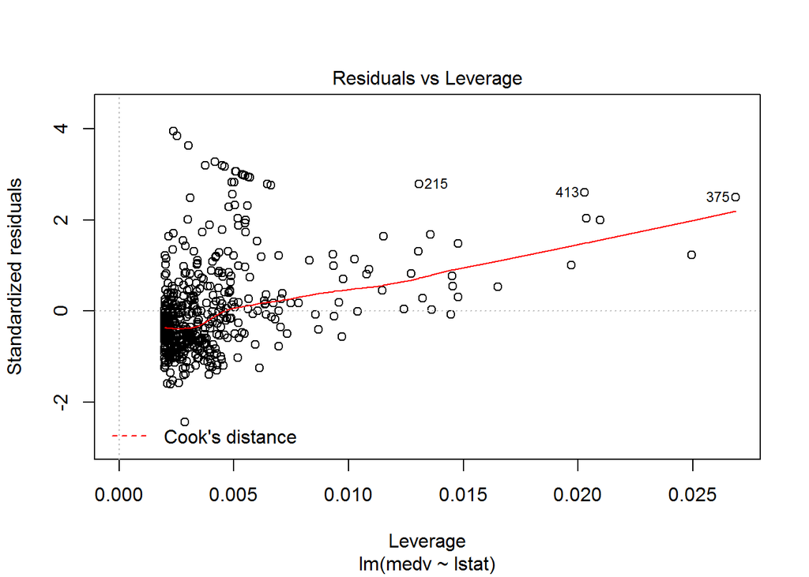

```r
plot(lstatModel)
```

```r
confint(lstatModel)
```

```
##                 2.5 %     97.5 %
## (Intercept) 33.448457 35.6592247
## lstat       -1.026148 -0.8739505
```

computing CI and PI using predict function lwd in abline in for increasing line width

```r
predict(lstatModel,data.frame(lstat=c(5,10,15)),interval ="confidence")
```

```
##        fit      lwr      upr
## 1 29.80359 29.00741 30.59978
## 2 25.05335 24.47413 25.63256
## 3 20.30310 19.73159 20.87461
```

```r
predict(lstatModel,data.frame(lstat=c(5,10,15)),interval ="prediction")
```

```
##        fit       lwr      upr
## 1 29.80359 17.565675 42.04151
## 2 25.05335 12.827626 37.27907
## 3 20.30310  8.077742 32.52846
```

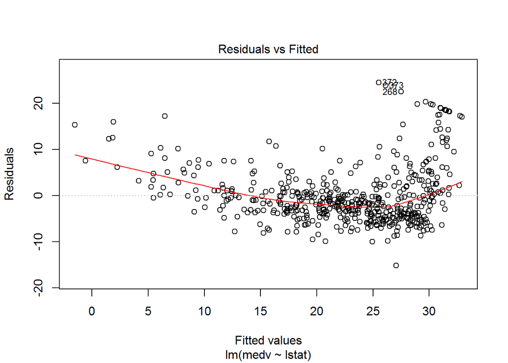

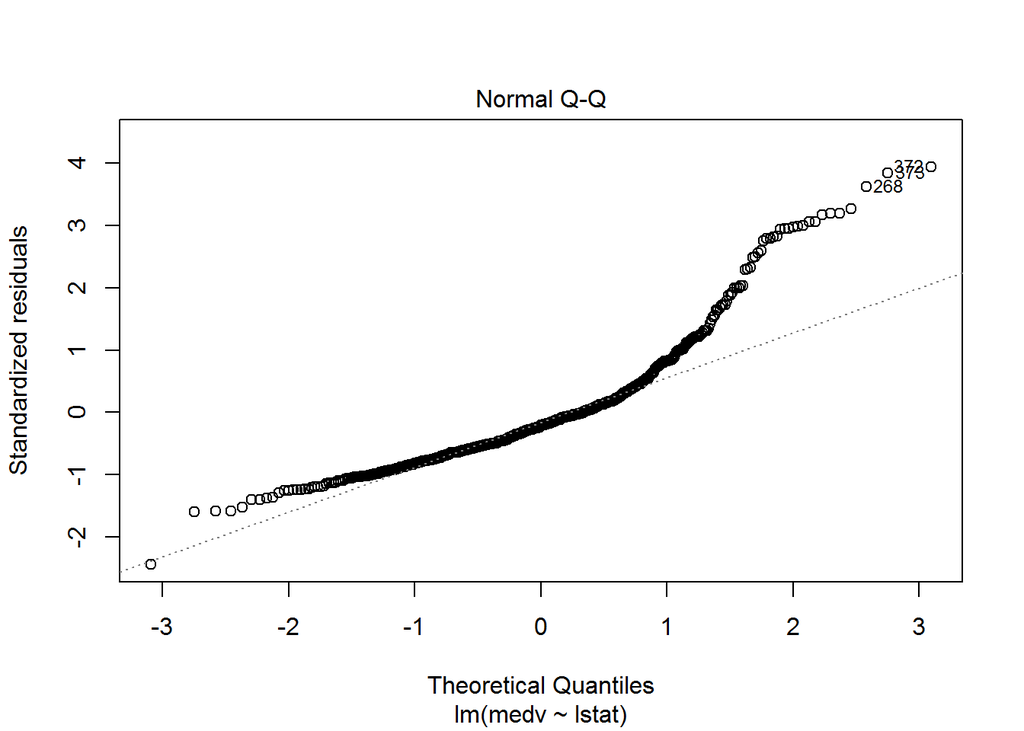

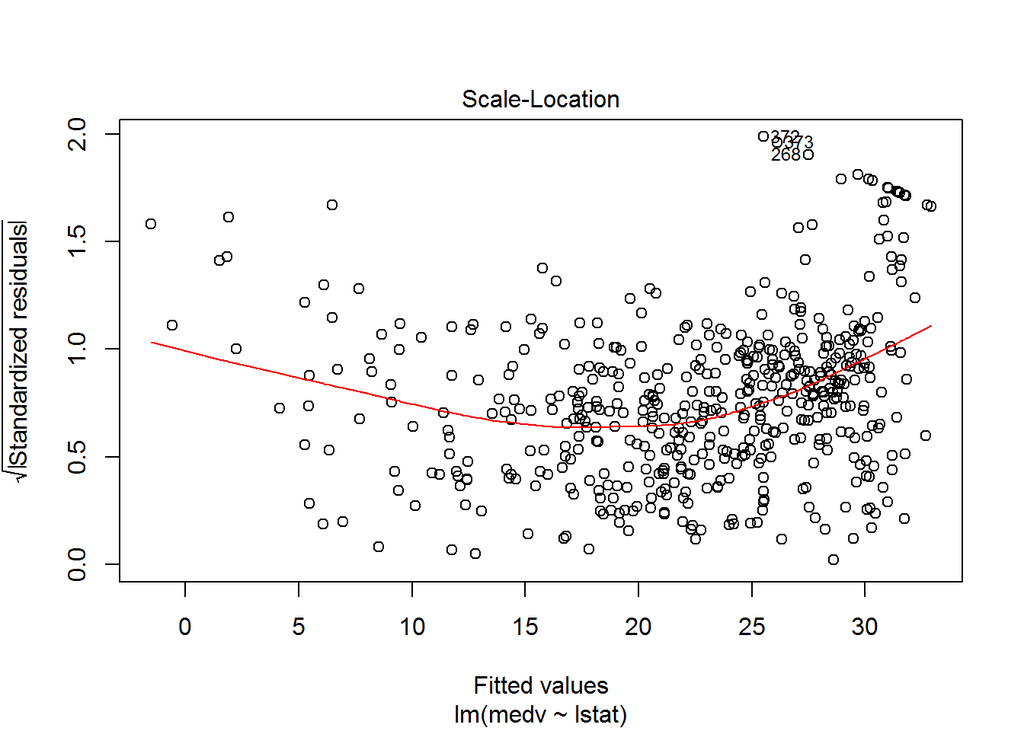

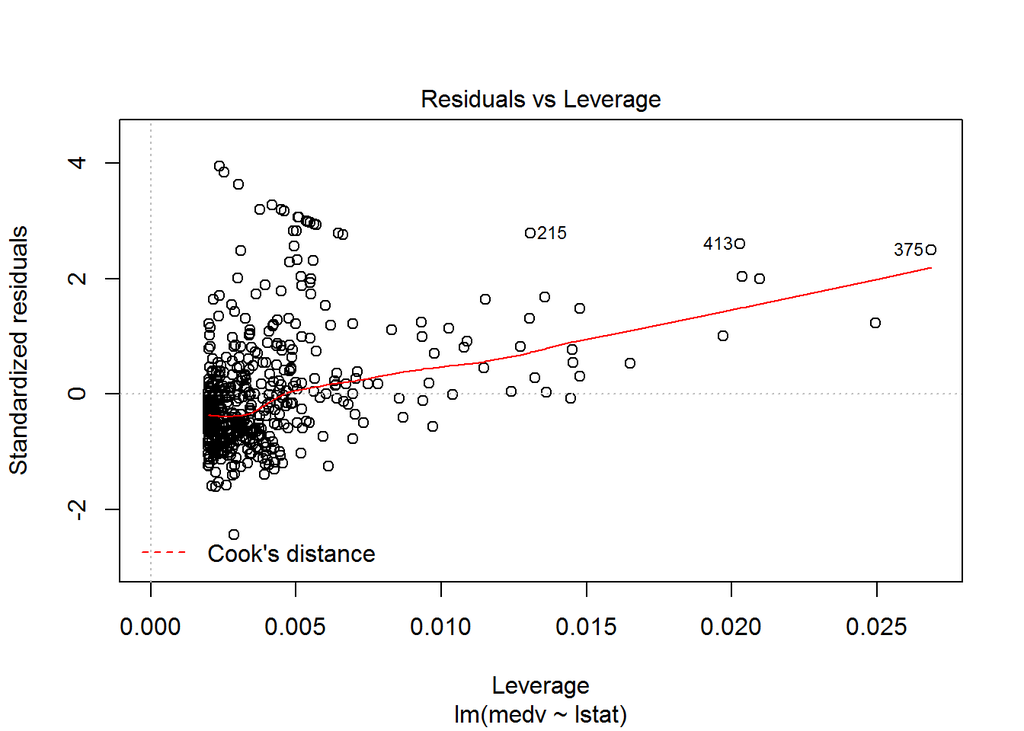

```r
plot(lstatModel)
```

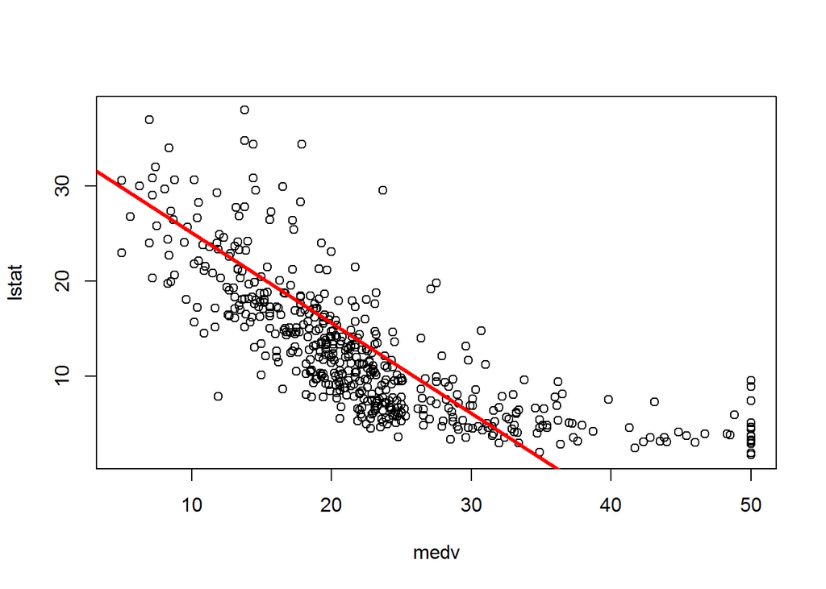

```r
plot(lstat~medv)
abline(lstatModel,col="red",lwd=3)
```

from the above plot there is evidence the relationship is non linear

```r
lstatnonL=lm(medv~lstat+I(lstat^2))
summary(lstatnonL)
```

```
##
## Call:
## lm(formula = medv ~ lstat + I(lstat^2))
##
## Residuals:
##      Min       1Q   Median       3Q      Max
## -15.2834  -3.8313  -0.5295   2.3095  25.4148
##
## Coefficients:
##              Estimate Std. Error t value Pr(>|t|)
## (Intercept) 42.862007   0.872084   49.15   <2e-16 ***
## lstat       -2.332821   0.123803  -18.84   <2e-16 ***
## I(lstat^2)   0.043547   0.003745   11.63   <2e-16 ***
## ---
## Signif. codes:  0 '***' 0.001 '**' 0.01 '*' 0.05 '.' 0.1 ' ' 1
##
## Residual standard error: 5.524 on 503 degrees of freedom
## Multiple R-squared:  0.6407, Adjusted R-squared:  0.6393
## F-statistic: 448.5 on 2 and 503 DF,  p-value: < 2.2e-16
```

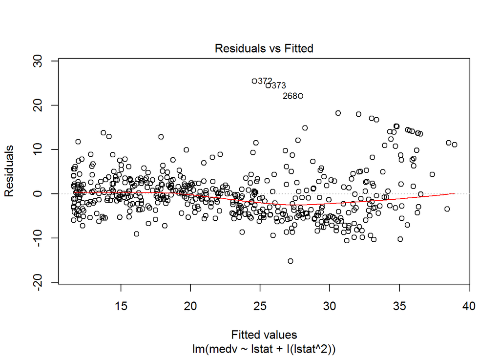

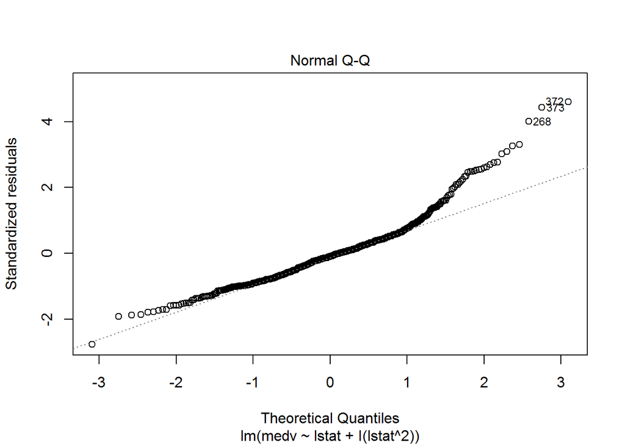

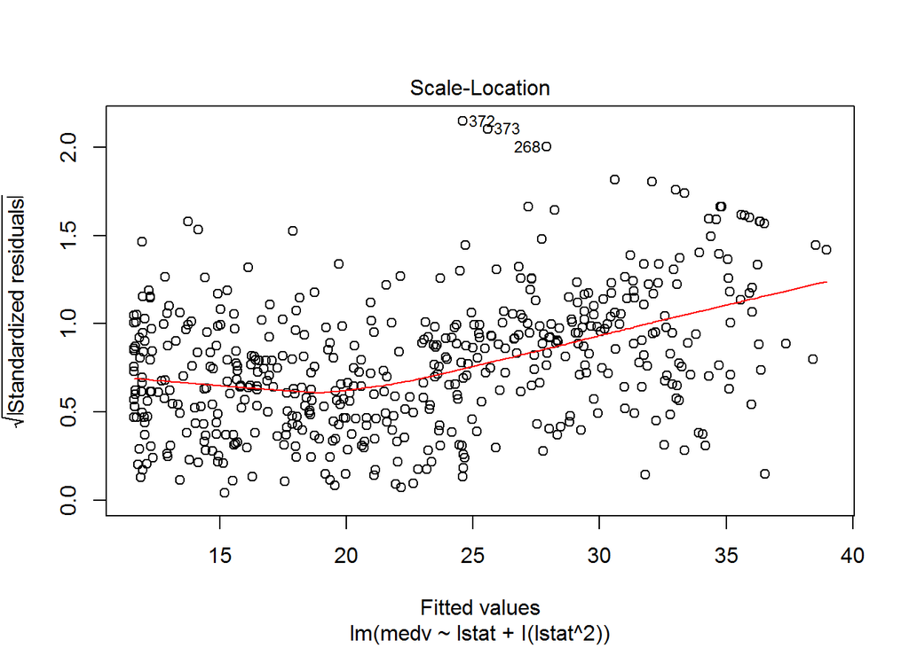

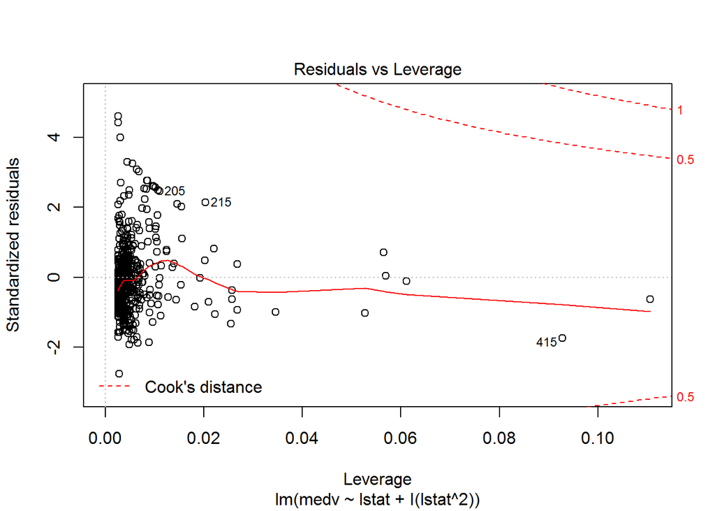

```r
plot(lstatnonL)
```

ploynomial upto 5

```r
lstatnonL=lm(medv~poly(lstat,5))
summary(lstatnonL)
```

```
##
## Call:
## lm(formula = medv ~ poly(lstat, 5))
##
## Residuals:
##      Min       1Q   Median       3Q      Max
## -13.5433  -3.1039  -0.7052   2.0844  27.1153
##
## Coefficients:
##                  Estimate Std. Error t value Pr(>|t|)
## (Intercept)       22.5328     0.2318  97.197  < 2e-16 ***
## poly(lstat, 5)1 -152.4595     5.2148 -29.236  < 2e-16 ***
## poly(lstat, 5)2   64.2272     5.2148  12.316  < 2e-16 ***
## poly(lstat, 5)3  -27.0511     5.2148  -5.187 3.10e-07 ***
## poly(lstat, 5)4   25.4517     5.2148   4.881 1.42e-06 ***
## poly(lstat, 5)5  -19.2524     5.2148  -3.692 0.000247 ***
## ---
## Signif. codes:  0 '***' 0.001 '**' 0.01 '*' 0.05 '.' 0.1 ' ' 1
##
## Residual standard error: 5.215 on 500 degrees of freedom
## Multiple R-squared:  0.6817, Adjusted R-squared:  0.6785
## F-statistic: 214.2 on 5 and 500 DF,  p-value: < 2.2e-16
```

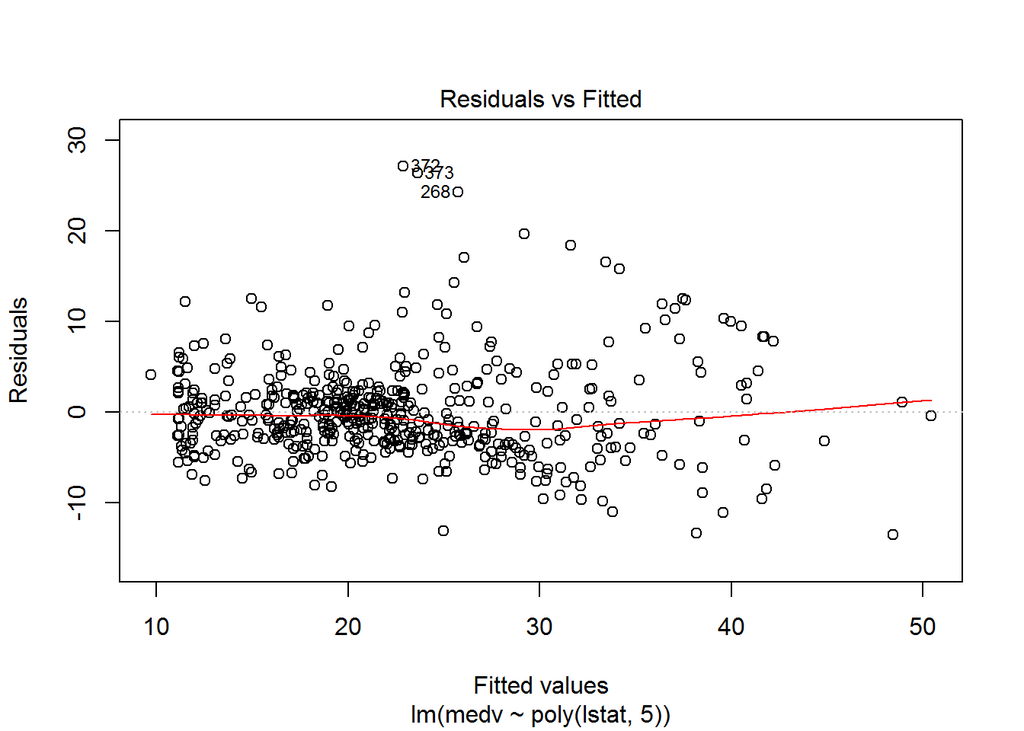

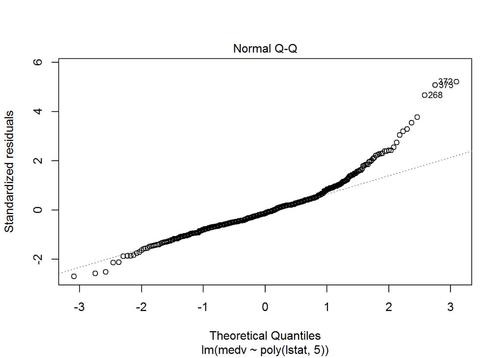

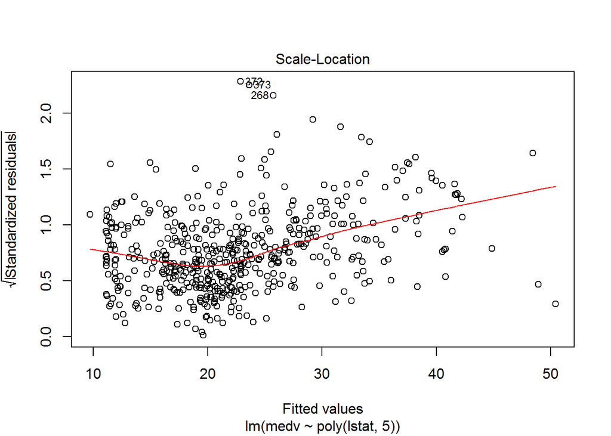

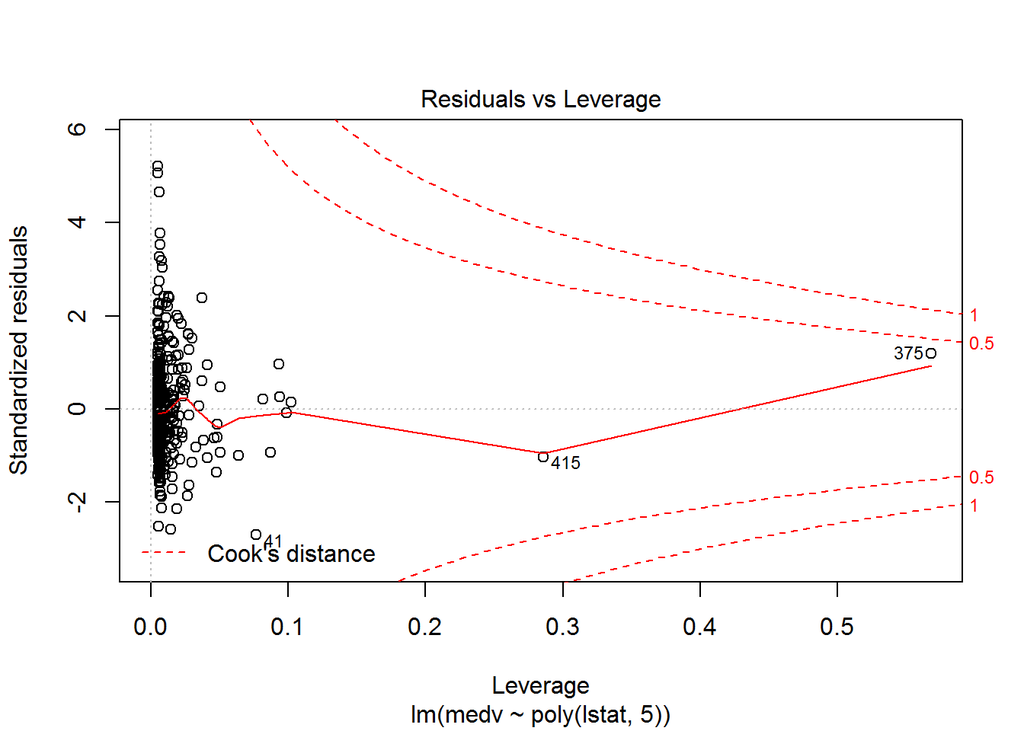

```r
plot(lstatnonL)
```

fitting step wise in r

```r
lstatModel2=lm(medv~crim+zn+chas+nox+rm+dis+rad+tax+ptratio+black+lstat)
summary(lstatModel2)
```

```
##
## Call:
## lm(formula = medv ~ crim + zn + chas + nox + rm + dis + rad +
##     tax + ptratio + black + lstat)
##
## Residuals:
##      Min       1Q   Median       3Q      Max
## -15.5984  -2.7386  -0.5046   1.7273  26.2373
##
## Coefficients:
##               Estimate Std. Error t value Pr(>|t|)
## (Intercept)  36.341145   5.067492   7.171 2.73e-12 ***
## crim         -0.108413   0.032779  -3.307 0.001010 **
## zn            0.045845   0.013523   3.390 0.000754 ***
## chas          2.718716   0.854240   3.183 0.001551 **
## nox         -17.376023   3.535243  -4.915 1.21e-06 ***
## rm            3.801579   0.406316   9.356  < 2e-16 ***
## dis          -1.492711   0.185731  -8.037 6.84e-15 ***
## rad           0.299608   0.063402   4.726 3.00e-06 ***
## tax          -0.011778   0.003372  -3.493 0.000521 ***
## ptratio      -0.946525   0.129066  -7.334 9.24e-13 ***
## black         0.009291   0.002674   3.475 0.000557 ***
## lstat        -0.522553   0.047424 -11.019  < 2e-16 ***
## ---
## Signif. codes:  0 '***' 0.001 '**' 0.01 '*' 0.05 '.' 0.1 ' ' 1
##
## Residual standard error: 4.736 on 494 degrees of freedom
## Multiple R-squared:  0.7406, Adjusted R-squared:  0.7348
## F-statistic: 128.2 on 11 and 494 DF,  p-value: < 2.2e-16
```

```r
anova(lstatModel,lstatModel2)
```

```
## Analysis of Variance Table
##
## Model 1: medv ~ lstat
## Model 2: medv ~ crim + zn + chas + nox + rm + dis + rad + tax + ptratio +
##     black + lstat
##   Res.Df   RSS Df Sum of Sq      F    Pr(>F)
## 1    504 19472
## 2    494 11081 10      8391 37.407 < 2.2e-16 ***
## ---
## Signif. codes:  0 '***' 0.001 '**' 0.01 '*' 0.05 '.' 0.1 ' ' 1
```

cross validation with linear regression cv on the models lstatmodel1 and lstat model2

```r
library(DAAG)
cv1=cv.lm(data = Boston,lstatModel,m=3)
```

```
## Analysis of Variance Table
##
## Response: medv
##            Df Sum Sq Mean Sq F value Pr(>F)
## lstat       1  23244   23244     602 <2e-16 ***
## Residuals 504  19472      39
## ---
## Signif. codes:  0 '***' 0.001 '**' 0.01 '*' 0.05 '.' 0.1 ' ' 1
```

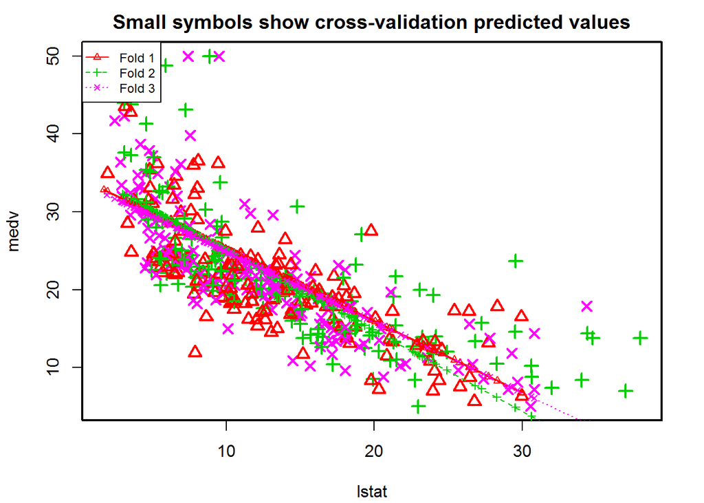

```
##
## fold 1
## Observations in test set: 168
##                 1     5     9    12    14    15    19    20    21    22
## lstat        4.98  5.33 29.93 13.27  8.26 10.26 11.69 11.28 21.02 13.83
## cvpred      29.83 29.50  6.78 22.17 26.80 24.95 23.63 24.01 15.01 21.65
## medv        24.00 36.20 16.50 18.90 20.40 18.20 20.20 18.20 13.60 19.60
## CV residual -5.83  6.70  9.72 -3.27 -6.40 -6.75 -3.43 -5.81 -1.41 -2.05
##                23    27    32    33    34    36    41      50    54    56
## lstat       18.72 14.81 13.04 27.71 18.35  9.68  1.98 16.2000  8.43  4.81
## cvpred      17.13 20.75 22.38  8.83 17.48 25.49 32.60 19.4623 26.64 29.98
## medv        15.20 16.60 14.50 13.20 13.10 18.90 34.90 19.4000 23.40 35.40
## CV residual -1.93 -4.15 -7.88  4.37 -4.38 -6.59  2.30 -0.0623 -3.24  5.42
##                59    60    61    63     64    65    68    70    73    75
## lstat        6.86  9.22 13.15  6.73  9.500  8.05  8.10  8.79  5.52  6.78
## cvpred      28.09 25.91 22.28 28.21 25.652 26.99 26.95 26.31 29.33 28.16
## medv        23.30 19.60 18.70 22.20 25.000 33.00 22.00 20.90 22.80 24.10
## CV residual -4.79 -6.31 -3.58 -6.01 -0.652  6.01 -4.95 -5.41 -6.53 -4.06
##                80    82    88    89   103   107   108   112   115   116
## lstat        9.10  7.22  8.44  5.50 10.63 18.66 14.09 10.16 10.45 15.76
## cvpred      26.02 27.76 26.63 29.35 24.61 17.19 21.41 25.04 24.77 19.87
## medv        20.30 23.90 22.20 23.60 18.60 19.50 20.40 22.80 18.50 18.30
## CV residual -5.72 -3.86 -4.43 -5.75 -6.01  2.31 -1.01 -2.24 -6.27 -1.57
##               118   123   124    125   128   129   134   135   138   149
## lstat       10.30 17.93 25.41 17.580 17.19 15.39 15.03 17.31 14.59 28.32
## cvpred      24.91 17.86 10.95 18.187 18.55 20.21 20.54 18.44 20.95  8.27
## medv        19.20 20.50 17.30 18.800 16.20 18.00 18.40 15.60 17.10 17.80
## CV residual -5.71  2.64  6.35  0.613 -2.35 -2.21 -2.14 -2.84 -3.85  9.53
##                 151   153    154   159   162  167    168  171   177   178
## lstat       14.1000 12.12 15.790  6.43  1.73  3.7 12.140 14.4 10.11  6.29
## cvpred      21.4023 23.23 19.841 28.49 32.83 31.0 23.213 21.1 25.09 28.62
## medv        21.5000 15.30 19.400 24.30 50.00 50.0 23.800 17.4 23.20 24.60
## CV residual  0.0977 -7.93 -0.441 -4.19 17.17 19.0  0.587 -3.7 -1.89 -4.02
##               179   182   185    192   194   196   199   202   206    207
## lstat        6.92  9.45 13.98  4.690  5.03  2.97  6.62  7.43 10.87 10.970
## cvpred      28.04 25.70 21.51 30.095 29.78 31.68 28.31 27.56 24.39 24.294
## medv        29.90 36.20 26.40 30.500 31.10 50.00 34.60 24.10 22.60 24.400
## CV residual  1.86 10.50  4.89  0.405  1.32 18.32  6.29 -3.46 -1.79  0.106
##               211   213   217   223   224   226   228    230    231   234
## lstat       17.27 16.03 13.51  9.93  7.60  4.63  6.36  3.760 11.650  3.95
```

[output cut: 229 more lines]

```
## lstat        7.74 13.34 18.06 29.68 18.07 13.35 12.01 17.60 21.14 14.10
## cvpred      26.91 21.85 17.58  7.07 17.57 21.84 23.05 17.99 14.79 21.16
## medv        23.70 20.60 15.20  8.10 13.60 20.10 21.80 23.10 19.70 18.30
## CV residual -3.21 -1.25 -2.38  1.03 -3.97 -1.74 -1.25  5.11  4.91 -2.86
##               499
## lstat       12.92
## cvpred      22.23
## medv        21.20
## CV residual -1.03
##
## Sum of squares = 6635    Mean square = 39.3    n = 169
##
## Overall (Sum over all 169 folds)
##   ms
## 39.4
```

```r
cv2=cv.lm(Boston,lstatModel2,m=3)
```

```
## Analysis of Variance Table
##
## Response: medv
##            Df Sum Sq Mean Sq F value  Pr(>F)
## crim        1   6441    6441  287.13 < 2e-16 ***
## zn          1   3554    3554  158.45 < 2e-16 ***
## chas        1   1234    1234   55.00 5.3e-13 ***
## nox         1   1592    1592   70.99 3.9e-16 ***
## rm          1  12091   12091  539.01 < 2e-16 ***
## dis         1   1122    1122   50.02 5.2e-12 ***
## rad         1     98      98    4.35   0.038 *
## tax         1    669     669   29.84 7.5e-08 ***
## ptratio     1   1520    1520   67.75 1.7e-15 ***
## black       1    591     591   26.33 4.1e-07 ***
## lstat       1   2723    2723  121.41 < 2e-16 ***
## Residuals 494  11081      22
## ---
## Signif. codes:  0 '***' 0.001 '**' 0.01 '*' 0.05 '.' 0.1 ' ' 1
```

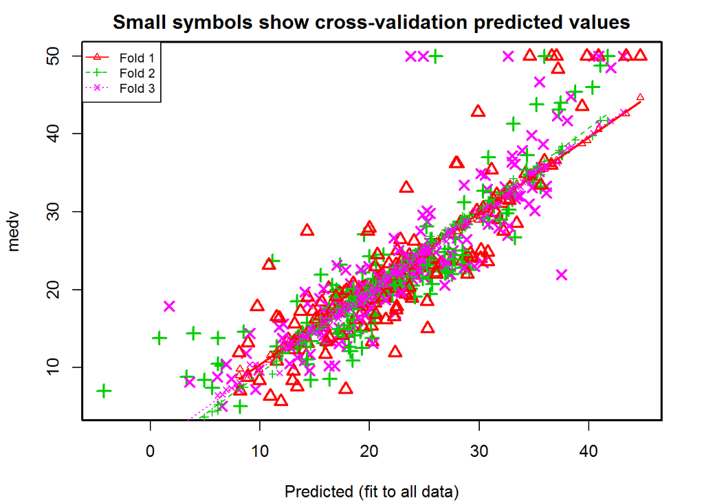

```
##
## fold 1
## Observations in test set: 168
##                 1     5     9    12     14    15    19     20     21    22
## Predicted   30.12 27.98 11.51 21.55 19.590 19.31 16.26 18.462 12.583 17.71
## cvpred      29.97 27.43 12.03 21.37 19.568 19.34 16.38 18.703 13.191 17.98
## medv        24.00 36.20 16.50 18.90 20.400 18.20 20.20 18.200 13.600 19.60
## CV residual -5.97  8.77  4.47 -2.47  0.832 -1.14  3.82 -0.503  0.409  1.62
##                23     27    32    33    34    36     41    50     54   56
## Predicted   15.88 15.498 18.09  8.89 14.34 23.87 34.229 17.18 24.017 31.1
## cvpred      16.32 15.712 18.26  9.39 14.79 24.01 34.219 17.32 23.786 30.7
## medv        15.20 16.600 14.50 13.20 13.10 18.90 34.900 19.40 23.400 35.4
## CV residual -1.12  0.888 -3.76  3.81 -1.69 -5.11  0.681  2.08 -0.386  4.7
##                59    60     61    63    64   65    68      70    73    75
## Predicted   21.75 21.06 17.844 23.94 22.51 23.3 21.14 20.8062 24.50 25.48
## cvpred      21.28 20.86 17.778 23.51 22.03 22.7 21.27 20.9611 24.49 25.71
## medv        23.30 19.60 18.700 22.20 25.00 33.0 22.00 20.9000 22.80 24.10
## CV residual  2.02 -1.26  0.922 -1.31  2.97 10.3  0.73 -0.0611 -1.69 -1.61
##                80   82    88    89   103   107  108   112  115   116  118
## Predicted   22.38 27.0 25.95 30.75 19.87 17.29 20.8 26.58 25.2 20.51 23.8
## cvpred      22.74 27.0 26.06 30.63 19.68 18.17 21.5 26.81 25.6 21.02 24.1
## medv        20.30 23.9 22.20 23.60 18.60 19.50 20.4 22.80 18.5 18.30 19.2
## CV residual -2.44 -3.1 -3.86 -7.03 -1.08  1.33 -1.1 -4.01 -7.1 -2.72 -4.9
##                 123    124   125    128   129   134   135   138   149
## Predicted   20.2314 16.058 20.23 15.089 18.84 15.65 13.16 19.26  9.74
## cvpred      20.5527 16.684 20.57 15.908 19.46 16.27 13.66 19.84 10.12
## medv        20.5000 17.300 18.80 16.200 18.00 18.40 15.60 17.10 17.80
## CV residual -0.0527  0.616 -1.77  0.292 -1.46  2.13  1.94 -2.74  7.68
##                151   153  154   159  162  167    168   171   177   178
## Predicted   20.818 20.15 17.3 28.89 36.6 37.0 22.963 22.42 25.72 29.22
## cvpred      20.511 20.13 16.9 28.87 36.2 36.6 22.875 22.54 25.75 29.08
## medv        21.500 15.30 19.4 24.30 50.0 50.0 23.800 17.40 23.20 24.60
## CV residual  0.989 -4.83  2.5 -4.57 13.8 13.4  0.925 -5.14 -2.55 -4.48
##               179   182   185    192   194   196     199   202    206
## Predicted   31.52 27.86 22.80 30.343 32.13 40.86 34.7098 29.34 22.673
## cvpred      31.36 27.94 23.08 30.248 32.16 40.57 34.6667 29.76 22.829
## medv        29.90 36.20 26.40 30.500 31.10 50.00 34.6000 24.10 22.600
## CV residual -1.46  8.26  3.32  0.252 -1.06  9.43 -0.0667 -5.66 -0.229
##                207   211    213   217   223    224  226    228    230
## Predicted   23.634 22.37 22.749 26.55 32.20 29.767 39.8 32.415 31.286
```

[output cut: 224 more lines]

```
## Predicted   27.00 19.41 11.79 3.63 13.69 15.85 20.73 17.01 14.12 19.194
## cvpred      26.17 18.89  9.31 1.81 11.35 13.31 19.93 16.59 13.82 18.635
## medv        23.70 20.60 15.20 8.10 13.60 20.10 21.80 23.10 19.70 18.300
## CV residual -2.47  1.71  5.89 6.29  2.25  6.79  1.87  6.51  5.88 -0.335
##                499
## Predicted   21.391
## cvpred      20.721
## medv        21.200
## CV residual  0.479
##
## Sum of squares = 4302    Mean square = 25.5    n = 169
##
## Overall (Sum over all 169 folds)
##   ms
## 23.3
```

```r
names(cv1)
```

```
##  [1] "crim"      "zn"        "indus"     "chas"      "nox"
##  [6] "rm"        "age"       "dis"       "rad"       "tax"
## [11] "ptratio"   "black"     "lstat"     "medv"      "Predicted"
## [16] "cvpred"
```

stepwise regression

```r
library(leaps)
```

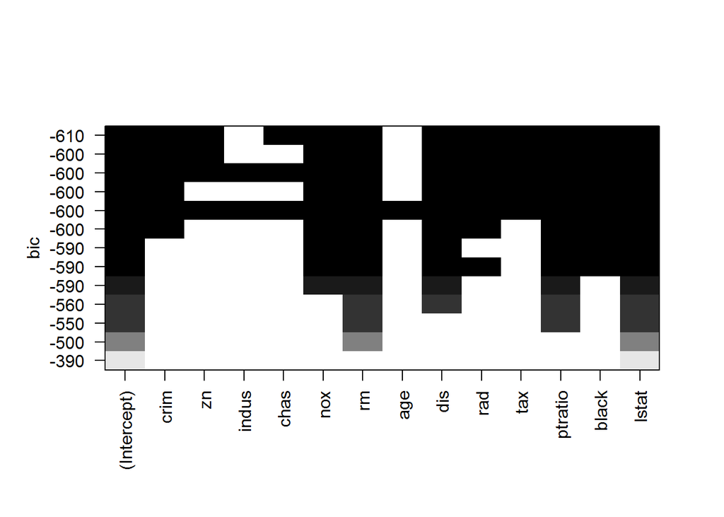

```r
stepmodel1=regsubsets(medv~.,data = Boston ,nvmax = 13,method =c("backward"))
plot(stepmodel1)
```

```r
stepmodel1sum=summary(stepmodel1)
names(stepmodel1)
```

```
##  [1] "np"        "nrbar"     "d"         "rbar"      "thetab"
##  [6] "first"     "last"      "vorder"    "tol"       "rss"
## [11] "bound"     "nvmax"     "ress"      "ir"        "nbest"
## [16] "lopt"      "il"        "ier"       "xnames"    "method"
## [21] "force.in"  "force.out" "sserr"     "intercept" "lindep"
## [26] "nullrss"   "nn"        "call"
```

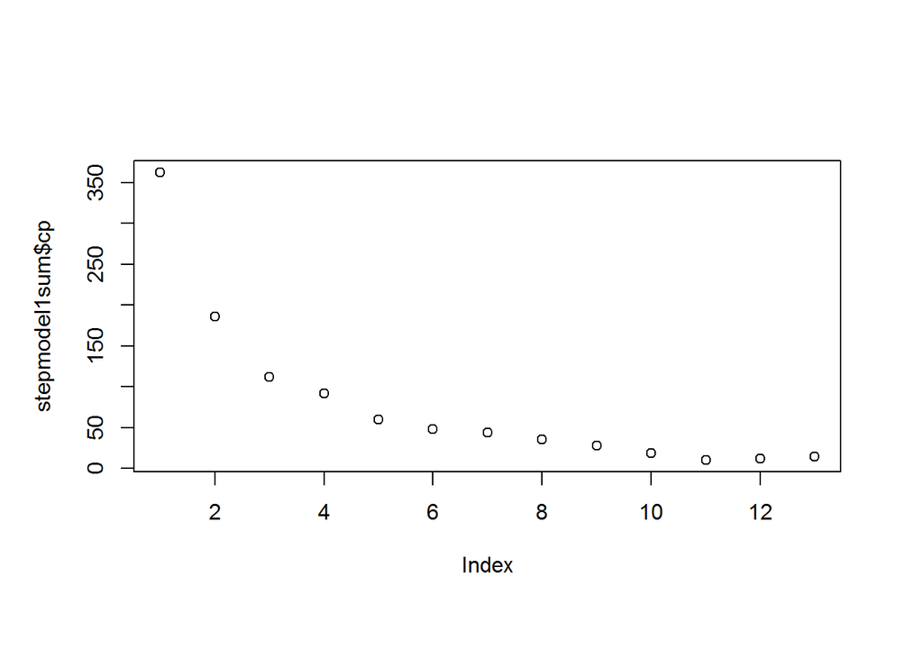

```r
plot(stepmodel1sum$cp)
```

```r
which.min(stepmodel1sum$cp)
```

```
## [1] 11
```

checking different model selection criterias

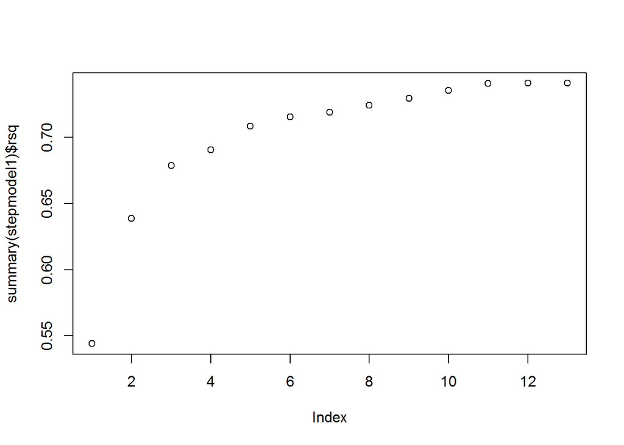

```r
 plot(summary(stepmodel1)$rsq)
```

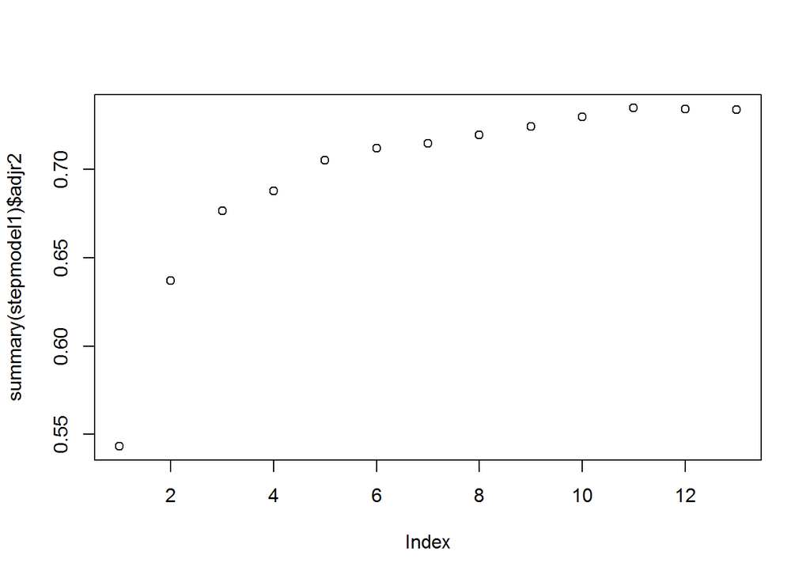

```r
 plot(summary(stepmodel1)$adjr2)
```

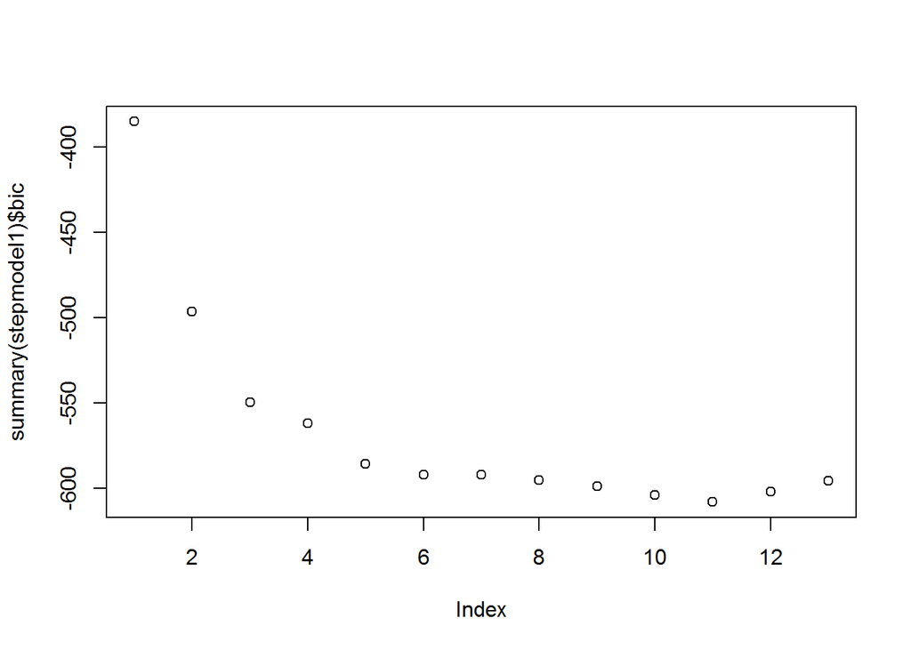

```r
 plot(summary(stepmodel1)$bic)
```

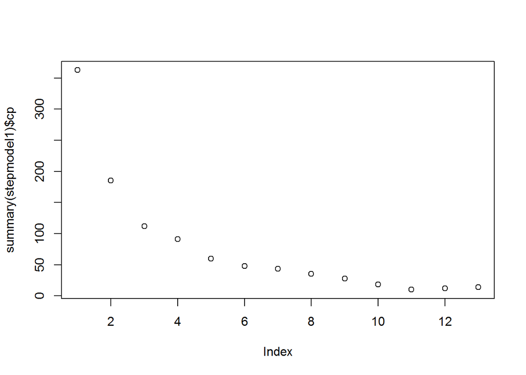

```r
 plot(summary(stepmodel1)$cp)
```

linear regression exercises

```r
attach(Auto)
Auto1=lm(mpg~horsepower)
summary(Auto1)
```

```
##
## Call:
## lm(formula = mpg ~ horsepower)
##
## Residuals:
##     Min      1Q  Median      3Q     Max
## -13.571  -3.259  -0.344   2.763  16.924
##
## Coefficients:
##             Estimate Std. Error t value Pr(>|t|)
## (Intercept) 39.93586    0.71750    55.7   <2e-16 ***
## horsepower  -0.15784    0.00645   -24.5   <2e-16 ***
## ---
## Signif. codes:  0 '***' 0.001 '**' 0.01 '*' 0.05 '.' 0.1 ' ' 1
##
## Residual standard error: 4.91 on 390 degrees of freedom
## Multiple R-squared:  0.606,  Adjusted R-squared:  0.605
## F-statistic:  600 on 1 and 390 DF,  p-value: <2e-16
```

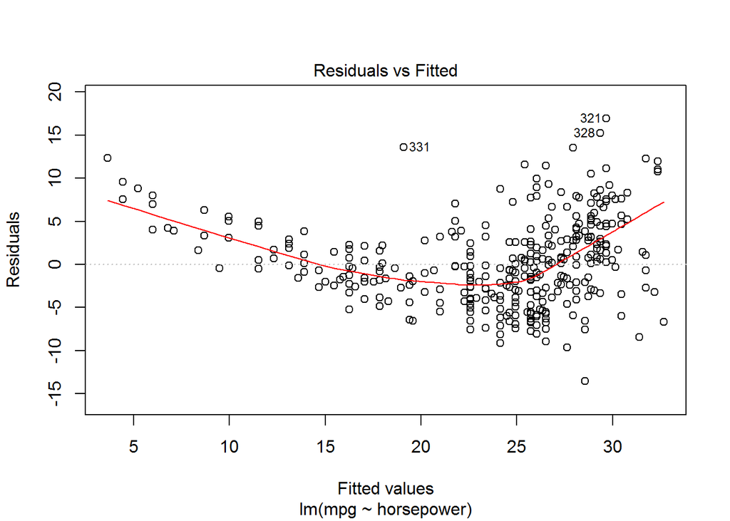

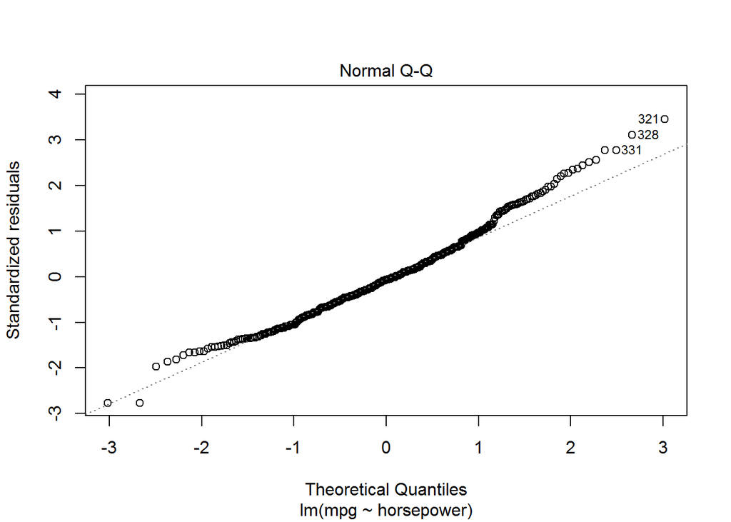

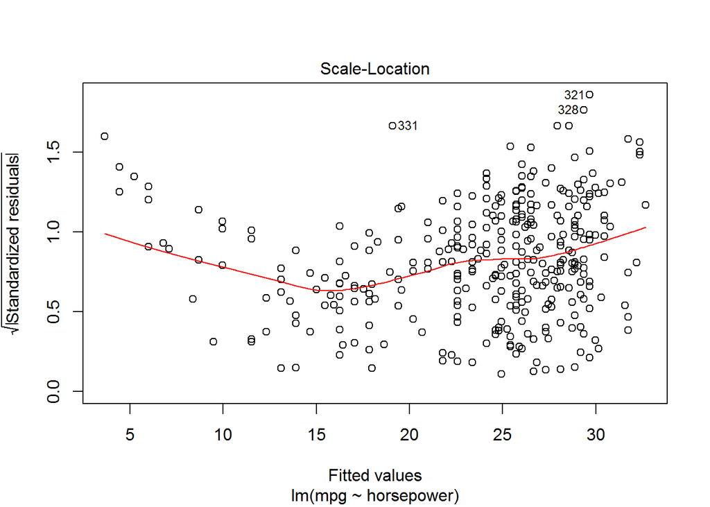

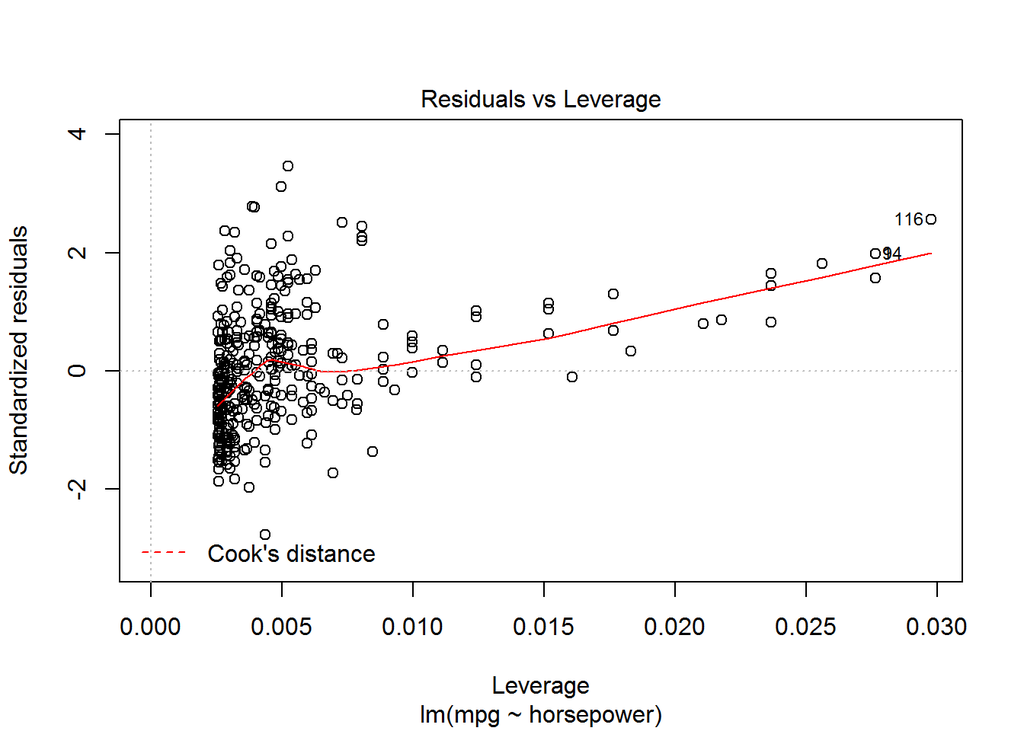

```r
plot(Auto1)
```

#predicting for value 98

```r
predict(Auto1,data.frame(horsepower=c(98)),interval="confidence")
```

```
##    fit lwr upr
## 1 24.5  24  25
```

```r
predict(Auto1,data.frame(horsepower=c(98)),interval="prediction")
```

```
##    fit  lwr  upr
## 1 24.5 14.8 34.1
```

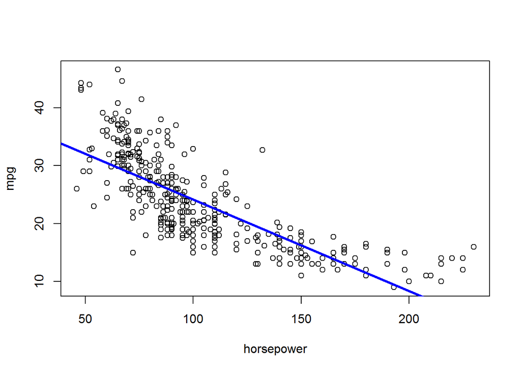

```r
plot(horsepower,mpg)
abline(Auto1,lwd=3,col="blue")
```